# cassi-thesis-sims

Dr. L and Cassi

2025-10-21

```r
# Load packages
library(rineq) ## for CI calculations
library(tidyverse) ## for data wrangling, etc

# Be reproducible queens
set.seed(205)

# Define colors
cols = c("#ff99ff", "#8bdddb", "#787ff6", "#ffbd59", "#7dd5f6", "#ff884d")
```

# Data Generation

We simulate samples of $n$ patients’ data in the following way.

1. $Z \sim Bernoulli(\pi = 0.2)$
2. $X|Z \sim Normal(\mu = 1 + 4Z, \sigma = 1)$
3. $R = \frac{Rank(X)-1}{n} + \frac{1}{2n}$
4. $Y|R \sim Normal(\mu = \alpha_1 + \beta_1R, \sigma = 1)$, where $\alpha_1$ and $\beta_1$ were chosen via grid search to balance (i) achieving particular values of the true concentration index and (ii) ensuring that the health outcome $Y$ remains nonnegative.
5. $X^* = X + U$, where $U \sim Normal(\mu = 0, \sigma = 0.5)$
6. $R^* = \frac{Rank(X^*)-1}{n} + \frac{1}{2n}$
7. $W = R^* - R$, such that an additive measurement error is assumed for the error-prone ranks: $R^* = R + W$.

The function below simulates data following this schema.

```r
# Function to simulate data- choose variance of errors, sample size, and coefficients for model (to simulate CI magnitude)
sim_ef_data = function(sigmaU, n, alpha1, beta1) {
  # 1) Rural/not rural indicator
  Z = rbinom(n = n, size = 1, prob = 0.2)

  # 2) True proximity | Rural / not rural
  X = rnorm(n = n, mean = 1 + 4 * Z, sd = 1)

  # Calculate rank
  R = (rank(X) - 1)/n + 1/(2 * n)

  # 3) Dietary inflammation score | Fractional rank of true proximity
  eps = rnorm(n = n, mean = 0, sd = 1)
  Y = alpha1 + beta1 * R + eps

  # Generate errors and error-prone X
  U = rnorm(n = n, mean = 0, sd = sigmaU)
  Xstar = X + U

  # Calculate error-prone rank
  Rstar = (rank(Xstar) - 1)/n + 1/(2 * n)
  w = Rstar - R

  # 4) Return
  data.frame(Y, X, R, Z, U, Xstar, Rstar, w, Y_bar = mean(Y))
}
```

# Concentration index and linear regression

Consider two linear regressions relating the health outcome $Y$ to the ranks based on the error-free and error-prone food access measures, respectively:

1. Error-free: $Y = \alpha_1 + \beta_1 R + \epsilon$ and
2. Error-prone: $Y = \alpha_1^* + \beta_1^* R^* + \epsilon^*$,

where $\epsilon$ and $\epsilon^*$ are assumed to follow their own normal distributions. (We simulated $Y$ such that $\epsilon$ follows a standard normal, specifically, but we don’t know the mean or standard deviation of $\epsilon^*$ necessarily.)

Importantly, these two models admit their own *expected* concentration indices:

1. Error-free: $C = \left(\frac{2\sigma_R^2}{\mu_Y}\right)\beta_1 = \left(\frac{2\sigma_R^2}{\alpha_1 + \beta_1/2}\right)\beta_1$
2. Error-pront: $C^* = \left(\frac{2\sigma_{R^*}^2}{\mu_Y}\right)\beta_1 = \left(\frac{2\sigma_{R^*}^2}{\alpha_1^* + \beta_1^*/2}\right)\beta_1^*$,

where $\sigma_R^2 = \sigma_{R^*}^2 \approx 0.08341$ is the variance of the fractional ranks (dictated only by the sample size $n = 1000$) and $\mu_Y = \textrm{E}(Y) = \textrm{E}\left\{\textrm{E}(Y|R)\right\} = \alpha_1 + \beta_1\textrm{E}(R) = \alpha_1 + \beta_1/2$ is the mean of the health outcome using the *law of iterated expectation* to get the marginal mean from the conditional distribution. (It should equivalently hold that $\mu_Y = \textrm{E}(Y) = \textrm{E}\left\{\textrm{E}(Y|R)\right\} = \alpha_1^* + \beta_1^*\textrm{E}(R^*) = \alpha_1^* + \beta_1^*/2$.)

The function below simulates a dataset, fits each of these models to it, and then returns the estimated coefficients.

```r
# Simulation to calculate the beta1/beta1* coefficients
simulate_betas = function(sigmaU, n, alpha1, beta1) {
  data = sim_ef_data(sigmaU = sigmaU,
                      n = n,
                      alpha1 = alpha1,
                      beta1 = beta1)
  mu_hat = data$Y_bar[1]
  var_r = var(data$R)
  var_w = var(data$Rstar - data$R)
  fit1 = lm(Y ~ R, data = data)
  fit2 = lm(Y ~ Rstar, data = data)
  alpha1_hat = fit1$coefficients[1]
  beta1_hat = fit1$coefficients[2]
  alpha1star_hat = fit2$coefficients[1]
  beta1star_hat = fit2$coefficients[2]
  return(data.frame(alpha1_hat,
                    beta1_hat,
                    alpha1star_hat,
                    beta1star_hat,
                    mu_bar = mu_hat,
                    var_r = round(var_r, 8),
                    var_w))
}
```

Below, we run $10,000$ replications for samples of $n = 1000$ patients under each of the following three settings:

1. Negative concentration index: $\alpha_1 = 2.5$ and $\beta_1 = -3$,
2. Zero concentration index: $\alpha_1 = 3$ and $\beta_1 = 0$, and
3. Positive concentration index: $\alpha_1 = -0.5$ and $\beta_1 = 3$.

```r
df_low_betas = do.call(what = rbind,
                       args = replicate(n = 10000,
                                        expr = simulate_betas(sigmaU = 0.5,
                                                              n = 1000,
                                                              alpha1 = 2.5,
                                                              beta1 = -3),
                                        simplify = FALSE))
df_zero_betas = do.call(what = rbind,
                        args = replicate(n = 10000,
                                         expr = simulate_betas(sigmaU = 0.5,
                                                               n = 1000,
                                                               alpha1 = 3,
                                                               beta1 = 0),
                                         simplify = FALSE))
df_high_betas = do.call(what = rbind,
                        args = replicate(n = 10000,
                                         expr = simulate_betas(sigmaU = 0.5,
                                                               n = 1000,
                                                               alpha1 = -0.5,
                                                               beta1 = 3),
                                         simplify = FALSE))
```

Then, we stack the results from these three settings so that we can visualize the results together.

```r
df_betas = df_low_betas |>
  mutate(est_ci_mu = 2 * var_r / mu_bar * beta1_hat,
         est_ci_alpha_beta = 2 * var_r / (alpha1_hat + (beta1_hat / 2)) * beta1_hat,
         est_ci_mu_star = 2 * var_r / mu_bar * beta1star_hat,
         est_ci_alpha_beta_star = 2 * var_r / (alpha1star_hat + (beta1star_hat / 2)) * beta1star_hat,
         approx_ci = -0.5,
         alpha1 = 2.5,
         beta1 = -3,
         exp_mu = alpha1 + beta1 * 0.5,
         exp_ci_mu = 2 * var_r / exp_mu * beta1,
         exp_ci_alpha_beta = 2 * var_r / (alpha1 + (beta1 / 2)) * beta1) |>
  bind_rows(
    df_zero_betas |>
      mutate(est_ci_mu = 2 * var_r / mu_bar * beta1_hat,
             est_ci_alpha_beta = 2 * var_r / (alpha1_hat + (beta1_hat / 2)) * beta1_hat,
             est_ci_mu_star = 2 * var_r / mu_bar * beta1star_hat,
             est_ci_alpha_beta_star = 2 * var_r / (alpha1star_hat + (beta1star_hat / 2)) * beta1star_hat,
             approx_ci = 0.0,
             alpha1 = 3,
             beta1 = 0,
             exp_mu = alpha1 + beta1 * 0.5,
             exp_ci_mu = 2 * var_r / exp_mu * beta1,
             exp_ci_alpha_beta = 2 * var_r / (alpha1 + (beta1 / 2)) * beta1)
  ) |>
  bind_rows(
    df_high_betas |>
      mutate(est_ci_mu = 2 * var_r / mu_bar * beta1_hat,
             est_ci_alpha_beta = 2 * var_r / (alpha1_hat + (beta1_hat / 2)) * beta1_hat,
             est_ci_mu_star = 2 * var_r / mu_bar * beta1star_hat,
             est_ci_alpha_beta_star = 2 * var_r / (alpha1star_hat + (beta1star_hat / 2)) * beta1star_hat,
             approx_ci = 0.5,
             alpha1 = -0.5,
             beta1 = 3,
             exp_mu = alpha1 + beta1 * 0.5,
             exp_ci_mu = 2 * var_r / exp_mu * beta1,
             exp_ci_alpha_beta = 2 * var_r / (alpha1 + (beta1 / 2)) * beta1)
  )
```

# Results

## Both concentration index calculations (using $\bar{Y}$ or $$\hat{\alpha}_1$ and $\hat{\beta}_1$) were empirically unbiased and equal to each other when using ranks based on error-free $X$

```r
# CHECK: expected CI based on mu or alpha/beta are equal
with(df_betas, table(exp_ci_mu == exp_ci_alpha_beta))
```

```
##
##  TRUE
## 30000
```

```r
# CHECK: estimated CI based on mu or alpha/beta are not exactly equal
with(df_betas, table(est_ci_mu == est_ci_alpha_beta))
```

```
##
## FALSE  TRUE
## 27835  2165
```

```r
## (but they're within 15 decimal places...)
with(df_betas, summary(est_ci_mu - est_ci_alpha_beta))
```

```
##       Min.    1st Qu.     Median       Mean    3rd Qu.       Max.
## -2.442e-15 -8.674e-18  1.084e-18  1.378e-16  4.441e-16  2.887e-15
```

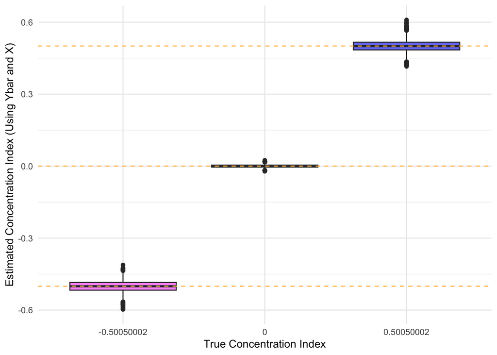

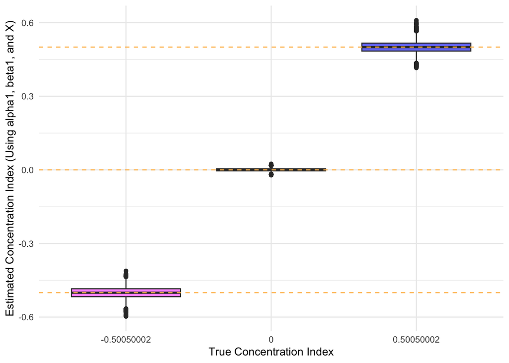

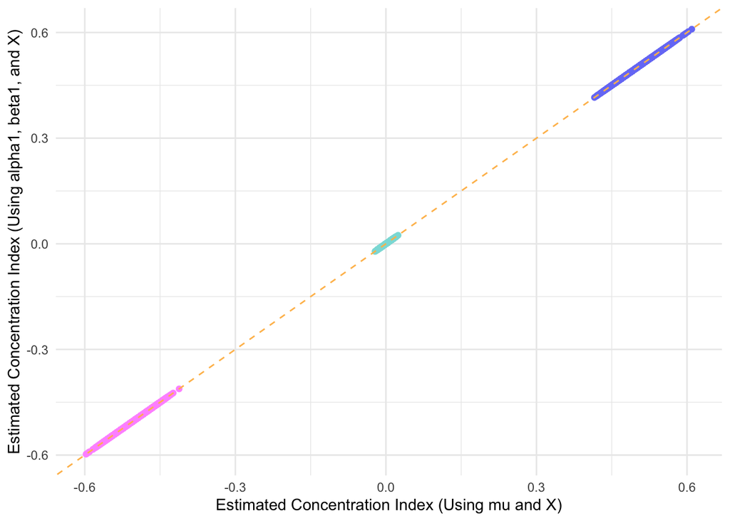

## Both concentration index calculations (using $\bar{Y}$ or $$\hat{\alpha}_1$ and $\hat{\beta}_1$) were empirically biased but equal to each other when using ranks based on error-prone $X^*$

```r
# CHECK: estimated CI based on mu or alpha/beta are not exactly equal
with(df_betas, table(est_ci_mu_star == est_ci_alpha_beta_star))
```

```
##
## FALSE  TRUE
## 27958  2042
```

```r
## (but they're within 15 decimal places...)
with(df_betas, summary(est_ci_mu_star - est_ci_alpha_beta_star))
```

```
##       Min.    1st Qu.     Median       Mean    3rd Qu.       Max.
## -2.276e-15 -8.782e-18  1.301e-18  1.217e-16  3.886e-16  3.220e-15
```

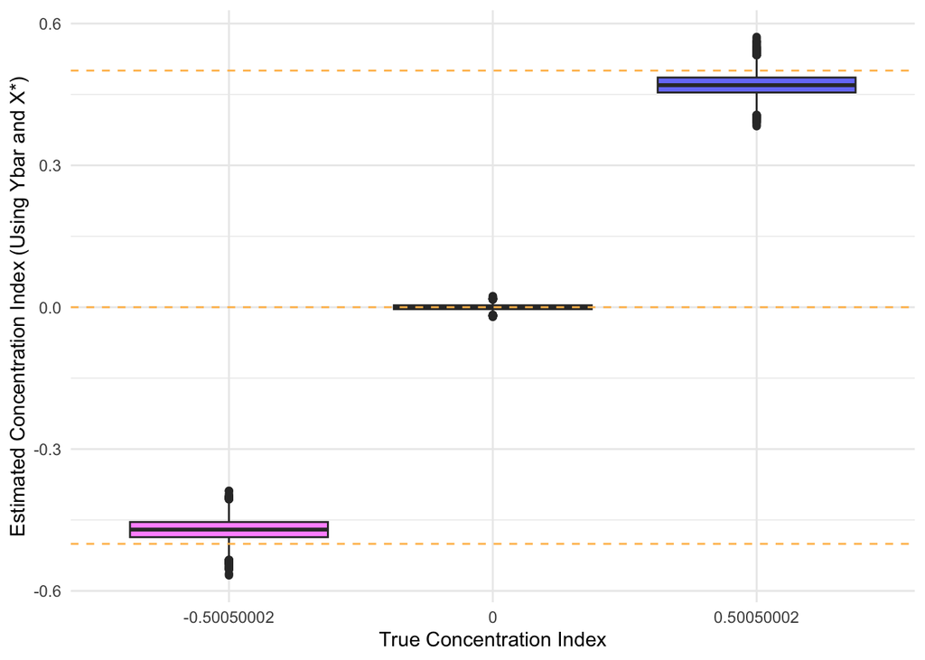

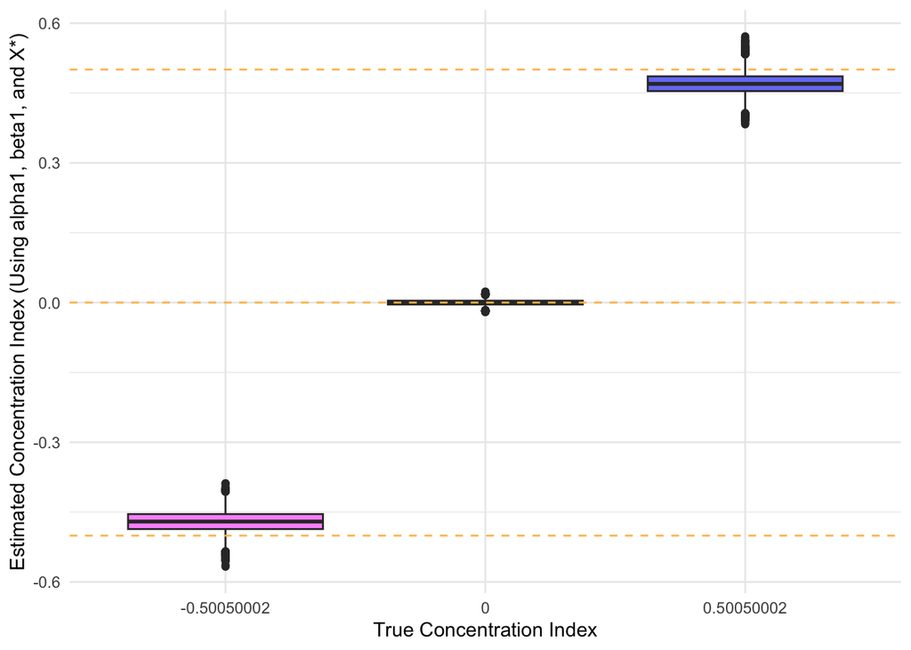

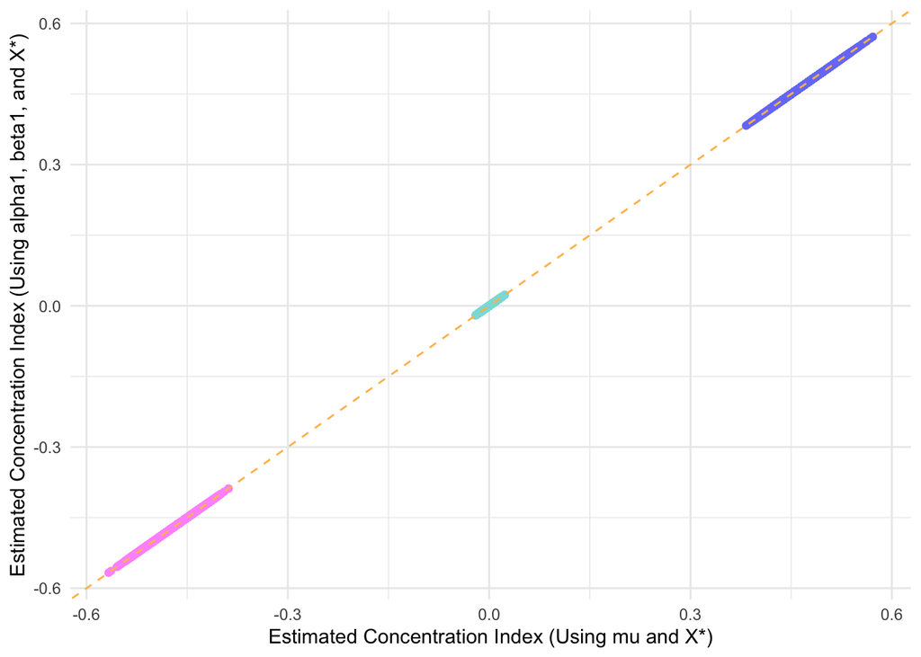